# Kaggle’s Credit Card Fraud Detection Analysis

Fan Kiat Chan (fchan5@illinois.edu)

May 5, 2021

## Abstract

The goal of this analysis is to use available data for creating a detection tool for credit card frauds. Data was first transformed to remedy the issue of data imbalance. Different modeling approaches are then explored, compared and analyzed. The results show good accuracies on training dataset for the different models, where further evaluation performed on the test data using the simplest model (decision tree) present accurate predictions as well.

## Introduction

This analysis attempts to seek a reasonable model using available data for detecting credit card fraud. Since countless transactions happen over credit card payments daily, it is important that credit card companies are able to keep track of these transactions and to recognize fraudulent activities quickly so that customers are not charged for items they did not purchase. We note here that this is an exercise in the context of materials learned in a course ([STAT432](https://stat432.org/) @ [UIUC](https://illinois.edu/)), and the models and results presented here are not, under any circumstances, a conclusive claim on the existence of a fraudulent activity. Please consult your credit card representative if you suspect any fraudulent activity on your credit statements.

## Methods

Here we describe the data used and how it is processed before fitting to a few models for analysis.

### Data

We will be using the [Kaggle Credit Card Fraud Detection](https://www.kaggle.com/mlg-ulb/creditcardfraud) for our analysis. The data can be downloaded using the `make-data.R` script, which will create the data file in `data/cc-sub.csv`. We can then load and take a quick look at the data.

```r
# cc_sub = read_csv("data/cc-sub.csv", col_types = cols())
cc_sub = data.table::fread("data/cc-sub.csv")
cc_sub
```

```
##          Time         V1         V2         V3          V4         V5
##     1:  49821 -0.7502343  1.1754267  1.5595377 -0.20901999  0.1305026
##     2:  46444 -0.8175723  0.8090505  1.3290570 -0.01947022  1.3056713
##     3:  67173  1.2369726 -1.5216076  1.2869277 -0.95645464 -2.3059195
##     4:  55536 -2.7006726  2.1654046  0.4472568 -2.07782098  0.1870938
##     5:  42684  1.2113732 -1.5246436  0.9208605 -1.20729584 -2.0739754
##    ---
##  9996:  61051 -1.2525435  1.0220124  0.5251504 -0.56492036  0.6464132
##  9997:  32841  0.9061640 -0.5947690  0.2442484  0.30937172 -0.6338624
##  9998:  79261 -0.7874341  0.0137707  0.5713829 -1.20272439  2.5241505
##  9999:  67924 -3.0188332  2.6153743 -0.1888622 -1.64826978 -1.4099864
## 10000: 136507 -0.5122868  1.7329647 -1.2663120  0.89064754  1.3777953
##                 V6          V7          V8         V9         V10        V11
##     1: -0.22858583  0.56432193  0.16495107 -0.6191044  0.09696998  1.8830536
##     2:  0.58299576  0.75268701  0.18783551 -0.2774520 -0.87979303 -2.0151494
```

[output cut: 57 more lines]

We can see that the data is stored as a tibble of size 10,000 x 31. Each row of the tibble contains a sample data for an individual, each with 31 features represented by the columns. The meanings of each feature are as below:

- `V1`, `V2`, … `V28` - the principal components obtained with PCA (original features and background information about the data is not provided due to confidentiality issues)
- `Time` - seconds elapsed between each transaction and the first transaction in the dataset
- `Amount` - transaction amount
- `Class` - transaction label either as `fraud` (positive) or `genuine` (negative)

We then perform test-train split on the data and check for any missing values in the training data.

```r
# test-train split the data
set.seed(42)
trn_idx = createDataPartition(cc_sub$Class, p = 0.80, list = FALSE)
cc_trn = cc_sub[trn_idx, ]
cc_tst = cc_sub[-trn_idx, ]

# function to determine proportion of NAs in a vector
na_prop = function(x) {
  mean(is.na(x))
}

# check proportion of NAs in each column
sapply(cc_trn, na_prop)
```

```
##   Time     V1     V2     V3     V4     V5     V6     V7     V8     V9    V10
##      0      0      0      0      0      0      0      0      0      0      0
##    V11    V12    V13    V14    V15    V16    V17    V18    V19    V20    V21
##      0      0      0      0      0      0      0      0      0      0      0
##    V22    V23    V24    V25    V26    V27    V28 Amount  Class
##      0      0      0      0      0      0      0      0      0
```

Fortunately, we do not see any missing data. We need to further coerce the `Class` response variable as factors so as to facilitate the classification modeling later.

Taking a quick look at the training data, we quickly realize that the dataset is extremely unbalanced.

```r
prop.table(table(cc_trn$Class))
```

```
##
##   fraud genuine
##  0.0015  0.9985
```

Considering the proportions of the data classified as `fraud`, using a classifier that always detect no fraudulent activity would be 99.85% accurate. This indicates that the sensitivity to false negative is low, and signals that mean accuracy is not a good measure for the performance of the developed model. Instead we could look at other measures such as sensitivity and specificity as well as measuring the area under the receiver operating characteristic (ROC) curve.

To remedy this, we can transform the data and create samples via random sampling to possibly balance the data set. Here we use over-sampling minority (`fraud`) data to generate a sampled data that is balanced.

```r
set.seed(42)
cc_trn_sampled = ovun.sample(
  Class ~ .,
  data = cc_trn,
  method = "over",
  N = length(cc_trn$Class) * 2)$data
cc_trn_sampled$Class <- relevel(cc_trn_sampled$Class, "fraud")
# Check data proportion now
prop.table(table(cc_trn_sampled$Class))
```

```
##
##   fraud genuine
## 0.50075 0.49925
```

The data now looks more balanced. We can further look into the correlations between different feature variables and response variable.

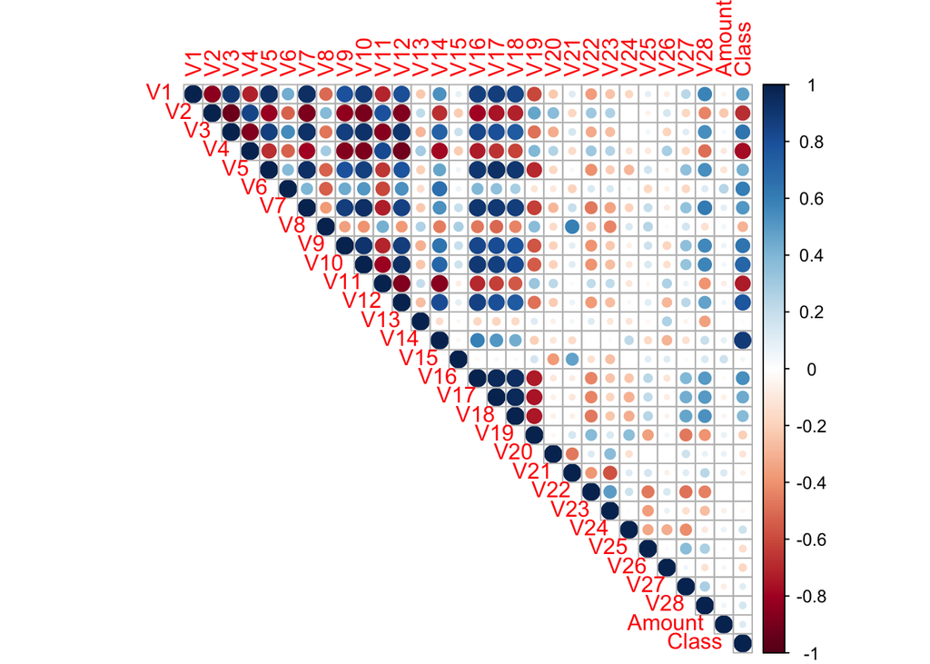

```r
cc_corr_viz = cc_trn_sampled
cc_corr_viz$Class = ifelse(cc_corr_viz$Class == "genuine", 1, 0)
corr_plot = corrplot(cor(cc_corr_viz[,-1]), method = "circle", type = "upper")
```

Looking at the correlations between `Class` and other feature variables, we see that there is a strong correlation with `V14`, `V12`, `V10` and `V9`. We should keep an eye on these variables later when we look at the models.

### Modeling

In our modeling, we will be using the 5-fold cross-validation approach for

- decision tree
- k-nearest neigbours
- random forest

```r
# cross-validation with decision tree, knn and random forest
cv_5 = trainControl(method = "cv",
                    number = 5,
                    )

# try with decision tree
cc_tree_mod = train(
  form = Class ~ .,
  data = cc_trn_sampled,
  method = "rpart",
  trControl = cv_5,
  tuneLength = 5
)

# try with knn
cc_knn_mod = train(
  form = Class ~ .,
  data = cc_trn_sampled,
  method = "knn",
  trControl = cv_5,
  tuneLength = 5
)

# try with random forest
cc_rf_mod = train(
  form = Class ~ .,
  data = cc_trn_sampled,
  method = "rf",
  trControl = cv_5,
  tuneLength = 5,
  verbose = FALSE
)
```

For brevity, we include final best model settings for each of these approaches in the appendix. Instead, we focus next on some metrics for evaluating the performance of these models, where we first compare the accuracies and the confusion matrices for these models.

## Results

Looking at the confusion matrices, we see that overall the models perform well, with knn showing some false positive predictions.

```r
confusionMatrix(cc_tree_mod)
```

```
## Cross-Validated (5 fold) Confusion Matrix
##
## (entries are percentual average cell counts across resamples)
##
##           Reference
## Prediction fraud genuine
##    fraud    50.1     0.0
##    genuine   0.0    49.9
##
##  Accuracy (average) : 0.9998
```

```r
confusionMatrix(cc_knn_mod)
```

```
## Cross-Validated (5 fold) Confusion Matrix
##
## (entries are percentual average cell counts across resamples)
##
##           Reference
## Prediction fraud genuine
##    fraud    50.1     0.5
##    genuine   0.0    49.4
##
##  Accuracy (average) : 0.9949
```

```r
confusionMatrix(cc_rf_mod)
```

```
## Cross-Validated (5 fold) Confusion Matrix
##
## (entries are percentual average cell counts across resamples)
##
##           Reference
## Prediction fraud genuine
##    fraud    50.1     0.0
##    genuine   0.0    49.9
##
##  Accuracy (average) : 0.9999
```

When looking at the ROC curves, we see that the area under the curve is close to 1 for all of these models.

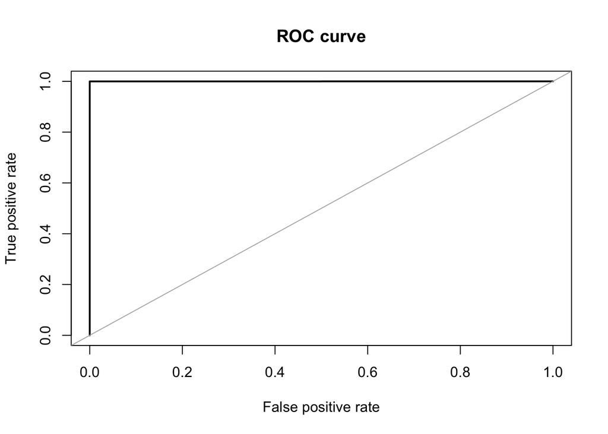

```
## Area under the curve (AUC): 1.000
```

```r
pred_tree = predict(cc_tree_mod, cc_trn_sampled, method = "class")
pred_knn = predict(cc_knn_mod, cc_trn_sampled, method = "class")
pred_rf = predict(cc_rf_mod, cc_trn_sampled, method = "class")

roc.curve(cc_trn_sampled$Class, pred_tree, plotit = TRUE)
```

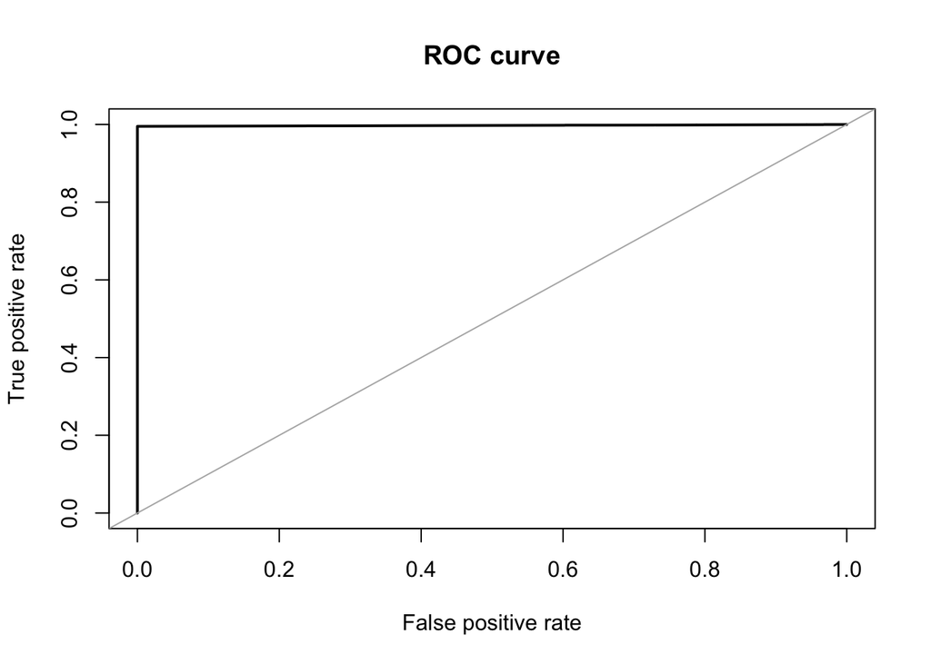

```
## Area under the curve (AUC): 0.998
```

```r
roc.curve(cc_trn_sampled$Class, pred_knn, plotit = TRUE)
```

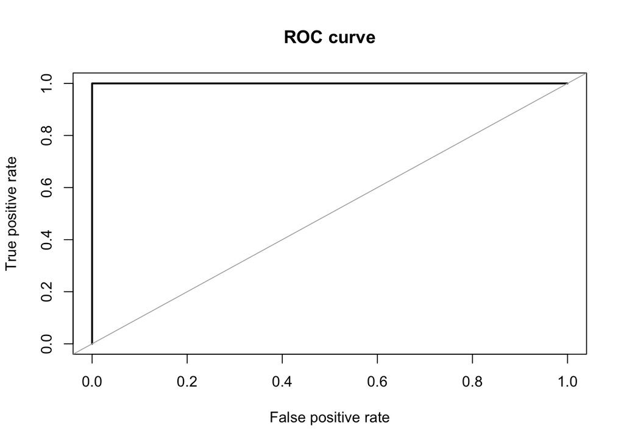

```
## Area under the curve (AUC): 1.000
```

```r
roc.curve(cc_trn_sampled$Class, pred_rf, plotit = TRUE)
```

## Discussion

Considering the similar performance of these models, we pick the decision tree model as our best model for testing. This is motivated by the simplicity of the model. It takes much less time to train and also prove to be simple to use by just following the flow of the decision tree chart as below.

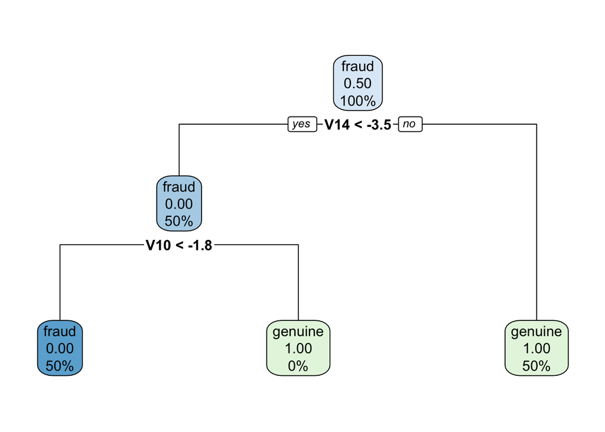

We further highlight the decision tree looks at two features: `V14` and `V10`, which is consistent with the observation of strong correlations between these features and the response variable `Class` as shown in the chart before.

Further evaluation of the decision tree model on a few other metrics (sensitivity, specificity, etc.) and ROC curve using the testing data shows the following results.

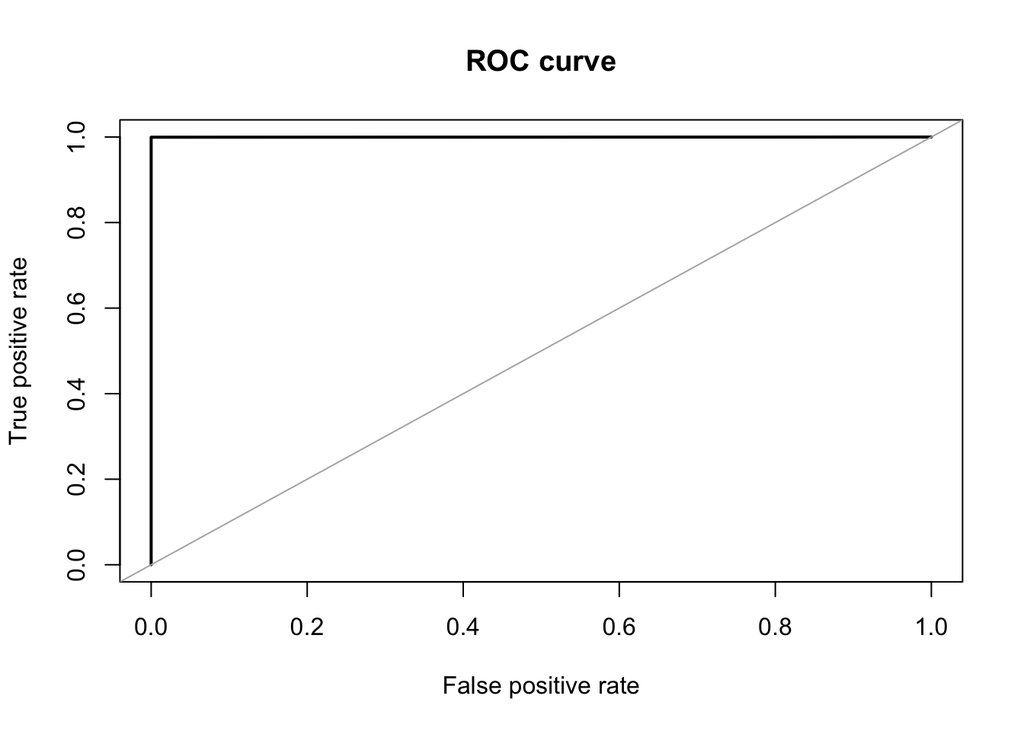

```
## Area under the curve (AUC): 1.000
```

```r
# test accuracy
pred_tst = predict(cc_tree_mod, cc_tst, method = "class")
roc.curve(cc_tst$Class, pred_tst, plotit = TRUE)
```

```r
confusionMatrix(data = pred_tst, reference = cc_tst$Class)
```

```
## Confusion Matrix and Statistics
##
##           Reference
## Prediction fraud genuine
##    fraud       3       1
##    genuine     0    1996
##
##                Accuracy : 0.9995
##                  95% CI : (0.9972, 1)
##     No Information Rate : 0.9985
##     P-Value [Acc > NIR] : 0.1989
##
##                   Kappa : 0.8569
##
##  Mcnemar's Test P-Value : 1.0000
##
##             Sensitivity : 1.0000
##             Specificity : 0.9995
##          Pos Pred Value : 0.7500
##          Neg Pred Value : 1.0000
##              Prevalence : 0.0015
##          Detection Rate : 0.0015
##    Detection Prevalence : 0.0020
##       Balanced Accuracy : 0.9997
##
##        'Positive' Class : fraud
##
```

As we can see from the ROC curve, the area under the curve is 1. The sensitivity is 1.0, which indicate that the model correctly predicts all existing frauds in the testing dataset. A disclaimer here though is that the samples marked as `fraud` (positive class) is extremely low due to sample imbalance. The specificity is 0.9995, which is still quite good, since detecting `genuine` activity as `fraud` (at a very low rate too!) is most likely acceptable, since it is better to be safe than sorry.

Overall, we have presented a few models that could be use to detect credit card frauds with good accuracy given the available unbalanced dataset, with decision tree chosen as our desired model given its simplicity in training and deployment. Future improvements that can be incorporated in the model development include taking a deeper look into feature variables that show strong correlations with response variable as highlighted above, and perhaps consult a financial professional for deciding which model, given the limitations, better augments the fraudulent detection pipeline. More balanced data set should also be used for fitting these models.

## Appendix

Below we show the optimal settings for each model used.

```r
cc_tree_mod
```

```
## CART
##
## 16000 samples
##    30 predictor
##     2 classes: 'fraud', 'genuine'
##
## No pre-processing
## Resampling: Cross-Validated (5 fold)
## Summary of sample sizes: 12799, 12801, 12800, 12800, 12800
## Resampling results across tuning parameters:
##
##   cp         Accuracy   Kappa
##   0.0000000  0.9998125  0.9996250
##   0.2493741  0.9986875  0.9973751
##   0.4987481  0.9986875  0.9973751
##   0.7481222  0.9986875  0.9973751
##   0.9974962  0.6996875  0.3983750
##
## Accuracy was used to select the optimal model using the largest value.
## The final value used for the model was cp = 0.
```

```r
cc_knn_mod
```

```
## k-Nearest Neighbors
##
## 16000 samples
##    30 predictor
##     2 classes: 'fraud', 'genuine'
##
## No pre-processing
## Resampling: Cross-Validated (5 fold)
## Summary of sample sizes: 12800, 12801, 12800, 12800, 12799
## Resampling results across tuning parameters:
##
##   k   Accuracy   Kappa
##    5  0.9948750  0.9897498
##    7  0.9932500  0.9864996
##    9  0.9911250  0.9822495
##   11  0.9891251  0.9782493
##   13  0.9874376  0.9748741
##
## Accuracy was used to select the optimal model using the largest value.
## The final value used for the model was k = 5.
```

```r
cc_rf_mod
```

```
## Random Forest
##
## 16000 samples
##    30 predictor
##     2 classes: 'fraud', 'genuine'
##
## No pre-processing
## Resampling: Cross-Validated (5 fold)
## Summary of sample sizes: 12800, 12799, 12801, 12800, 12800
## Resampling results across tuning parameters:
##
##   mtry  Accuracy   Kappa
##    2    0.9999375  0.999875
##    9    0.9998750  0.999750
##   16    0.9996875  0.999375
##   23    0.9996875  0.999375
##   30    0.9996875  0.999375
##
## Accuracy was used to select the optimal model using the largest value.
## The final value used for the model was mtry = 2.
```